# Tarea_2023

### Climate Change and Sea Ice Extent

We want to answer the question: Has there been a decrease in the amount of ice in the last years?

For that we will use the sea ice extent measurements (in millions of square km) from the [National Snow & Ice Data Center](https://nsidc.org), provided in file "SeaIce.txt".

We perform the following processing steps:

1. Read and clean the data.
2. Calculate Sea Ice Extent (SIE) anomalies and visualize its temporal trend.
3. Compute the SIE temporal trend as a simple linear regression (OLS) and quantitatively evaluate it.
4. Estimate the sea ice extent for 2025.

```python
import pandas as pd
import seaborn as sns
import matplotlib.pyplot as plt
import scipy.stats as stats
```

### 1. Read and clean the data.

Load the monthly sea ice extent (SIE) monthly data from provided in the file 'SeaIce.txt'. Note variables `extent` (SIE) and `area` should be greater or equal than zero. Detect possible outliers and clean the data.

```python
#your solution here
import pandas as pd

# Continue reading and processing the data
data = pd.read_csv('SeaIce.txt', delim_whitespace=True, comment='#', header=0)

print(data.head(20))

# Convert 'Extent' and 'Area' columns to numeric, replacing invalid values with NaN
data['extent'] = pd.to_numeric(data['extent'], errors='coerce')
data['area'] = pd.to_numeric(data['area'], errors='coerce')

# Drop rows with NaN values
data = data.dropna(subset=['extent', 'area'])

print('Ejemplo de valor anomalo: ')

print(data[(data['year'] == 1988) & (data['mo'] == 1)])

# Clean the data by removing rows with negative values (extent and area)
data = data[(data['extent'] >= 0) & (data['area'] >= 0)]

print(data.head(20)) #el año 1988 se ha filtrado de manera que ya no aparece en nuestro dataset
```

```
    year  mo data_type region   extent     area
0   1979   1   Goddard      N    15.54    12.33
1   1980   1   Goddard      N    14.96    11.85
2   1981   1   Goddard      N    15.03    11.82
3   1982   1   Goddard      N    15.26    12.11
4   1983   1   Goddard      N    15.10    11.92
5   1984   1   Goddard      N    14.61    11.60
6   1985   1   Goddard      N    14.86    11.60
7   1986   1   Goddard      N    15.02    11.79
8   1987   1   Goddard      N    15.20    11.81
9   1988   1     -9999      N -9999.00 -9999.00
10  1989   1   Goddard      N    15.12    13.11
11  1990   1   Goddard      N    14.95    12.72
12  1991   1   Goddard      N    14.46    12.49
13  1992   1   Goddard      N    14.72    12.54
```

[output cut: 30 more lines]

### 2. Calculate SIE anomalies and visualize its temporal trend.

Visualize whether there is a monthly dependence of SIE, explore the linear relationship using `lmplot`. Compute the mean and variance of SIE for each month. ¿Which are the months with higher variance?

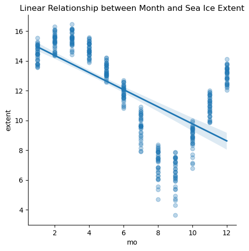

```
Mean and Variance of SIE for Each Month:
    mo       mean       var
0    1  14.479429  0.304906
1    2  15.298889  0.295804
2    3  15.491714  0.237209
3    4  14.766000  0.215378
4    5  13.396000  0.189901
5    6  11.860000  0.247918
6    7   9.601143  0.679175
7    8   7.122286  0.824577
8    9   6.404857  1.143902
9   10   8.809143  0.630361
10  11  10.964722  0.412511
11  12  13.059429  0.284870
Month with the Highest Variance: 9
```

```python
#your response here

# Create an lmplot to visualize the linear relationship between 'mo' and 'extent'
sns.lmplot(x='mo', y='extent', data=data, scatter_kws={'alpha': 0.3})
plt.title('Linear Relationship between Month and Sea Ice Extent')
plt.show()

# Compute the mean and variance of SIE for each month
monthly_statistics = data.groupby('mo')['extent'].agg(['mean', 'var']).reset_index() #agrupamos por mes y extent

# Identify the month with the highest variance
month_with_highest_variance = monthly_statistics[monthly_statistics['var'] == monthly_statistics['var'].max()]['mo'].values[0]

# Print the mean and variance of SIE for each month
print("Mean and Variance of SIE for Each Month:")
print(monthly_statistics)

# Print the month with the highest variance
print(f"Month with the Highest Variance: {month_with_highest_variance}")
```

Calculate SIE anomalies as the difference between the extent for the month in question and the mean for that month based on the January 1981 to December 2010 data. Then convert it to percent difference by dividing it by the 1981-2010 average for that month and then multiplying by 100.

Example using June 2012: The June mean extent, based on 1981 to 2010 data, is 11.89 million square km. This is the average of all the values in the extent column of the June Monthly Extent file from the 1981 to 2010 rows. The June 2012 anomaly is the difference between the extent value for June 2012 which is 10.92 million square km and the 1981-2010 June mean extent: 10.92 M sq km - 11.89 M sq km = -0.97 M sq km. The percent difference is then computed: (-0.97 / 11.89) X 100 = -8.16%.

Use the SIE anomaly for the rest of the exercise.

```python
df_anomalies = data.copy() # Make a copy to work with a new dataframe
# Calculate SIE (Sea Ice Extent) anomalies as the difference between the extent for the month in question and the mean for that month based on
# the January 1981 to December 2010 data. Then convert it to a percent difference by dividing it by the 1981-2010 average for
# that month and then multiplying by 100.

# Calculate the mean ice extent between 1981 and 2010 grouped by month
mean_reference_period = df_anomalies[(df_anomalies['year'] >= 1981) & (df_anomalies['year'] <= 2010)].groupby('mo')['extent'].mean()
mean_reference_period

# Calculate anomalies for each month and year
df_anomalies['Anomaly'] = df_anomalies.apply(lambda row: row['extent'] - mean_reference_period[row['mo']], axis=1)
df_anomalies['Percent_Anomaly'] = (df_anomalies['Anomaly'] / mean_reference_period[df_anomalies['mo'].values].values) * 100

df_anomalies.head()
df_anomalies['Percent_Anomaly'] = pd.to_numeric(df_anomalies['Percent_Anomaly'], errors='coerce')

# If the 'Anomaly' is positive, it means that the extent is greater than the reference average; if it is negative, it means that it is smaller.
# Analyze the trend of SIE anomaly per year considering: 1) all months, 2) January, 3) August

df_anomalies[df_anomalies['mo'] == 1] # Example of data for the month of January
```

|  | year | mo | data_type | region | extent | area | Anomaly | Percent_Anomaly |
| --- | --- | --- | --- | --- | --- | --- | --- | --- |
| 0 | 1979 | 1 | Goddard | N | 15.54 | 12.33 | 1.007931 | 6.935909 |
| 1 | 1980 | 1 | Goddard | N | 14.96 | 11.85 | 0.427931 | 2.944736 |
| 2 | 1981 | 1 | Goddard | N | 15.03 | 11.82 | 0.497931 | 3.426429 |
| 3 | 1982 | 1 | Goddard | N | 15.26 | 12.11 | 0.727931 | 5.009136 |
| 4 | 1983 | 1 | Goddard | N | 15.10 | 11.92 | 0.567931 | 3.908122 |
| 5 | 1984 | 1 | Goddard | N | 14.61 | 11.60 | 0.077931 | 0.536269 |
| 6 | 1985 | 1 | Goddard | N | 14.86 | 11.60 | 0.327931 | 2.256603 |
| 7 | 1986 | 1 | Goddard | N | 15.02 | 11.79 | 0.487931 | 3.357616 |
| 8 | 1987 | 1 | Goddard | N | 15.20 | 11.81 | 0.667931 | 4.596256 |
| 10 | 1989 | 1 | Goddard | N | 15.12 | 13.11 | 0.587931 | 4.045749 |
| 11 | 1990 | 1 | Goddard | N | 14.95 | 12.72 | 0.417931 | 2.875922 |
| 12 | 1991 | 1 | Goddard | N | 14.46 | 12.49 | -0.072069 | -0.495931 |
| 13 | 1992 | 1 | Goddard | N | 14.72 | 12.54 | 0.187931 | 1.293216 |
| 14 | 1993 | 1 | Goddard | N | 15.08 | 12.85 | 0.547931 | 3.770496 |
| 15 | 1994 | 1 | Goddard | N | 14.82 | 12.80 | 0.287931 | 1.981349 |
| 16 | 1995 | 1 | Goddard | N | 14.62 | 12.72 | 0.087931 | 0.605083 |
| 17 | 1996 | 1 | Goddard | N | 14.21 | 12.07 | -0.322069 | -2.216264 |
| 18 | 1997 | 1 | Goddard | N | 14.47 | 12.30 | -0.062069 | -0.427117 |
| 19 | 1998 | 1 | Goddard | N | 14.81 | 12.73 | 0.277931 | 1.912536 |
| 20 | 1999 | 1 | Goddard | N | 14.47 | 12.54 | -0.062069 | -0.427117 |
| 21 | 2000 | 1 | Goddard | N | 14.41 | 12.22 | -0.122069 | -0.839997 |
| 22 | 2001 | 1 | Goddard | N | 14.31 | 12.27 | -0.222069 | -1.528130 |
| 23 | 2002 | 1 | Goddard | N | 14.45 | 12.19 | -0.082069 | -0.564744 |
| 24 | 2003 | 1 | Goddard | N | 14.46 | 12.21 | -0.072069 | -0.495931 |
| 25 | 2004 | 1 | Goddard | N | 14.03 | 12.19 | -0.502069 | -3.454904 |
| 26 | 2005 | 1 | Goddard | N | 13.66 | 11.84 | -0.872069 | -6.000997 |
| 27 | 2006 | 1 | Goddard | N | 13.60 | 11.57 | -0.932069 | -6.413877 |
| 28 | 2007 | 1 | Goddard | N | 13.77 | 11.79 | -0.762069 | -5.244050 |
| 29 | 2008 | 1 | Goddard | N | 14.05 | 11.95 | -0.482069 | -3.317277 |
| 30 | 2009 | 1 | Goddard | N | 14.08 | 11.97 | -0.452069 | -3.110837 |
| 31 | 2010 | 1 | Goddard | N | 13.80 | 11.68 | -0.732069 | -5.037610 |
| 32 | 2011 | 1 | Goddard | N | 13.57 | 11.47 | -0.962069 | -6.620317 |
| 33 | 2012 | 1 | Goddard | N | 13.77 | 11.87 | -0.762069 | -5.244050 |
| 34 | 2013 | 1 | NRTSI-G | N | 13.78 | 11.57 | -0.752069 | -5.175237 |
| 35 | 2014 | 1 | NRTSI-G | N | 13.73 | 11.66 | -0.802069 | -5.519303 |

Visualize the trend of SIE anomaly per year considering:1) all months, 2) January, 3) August

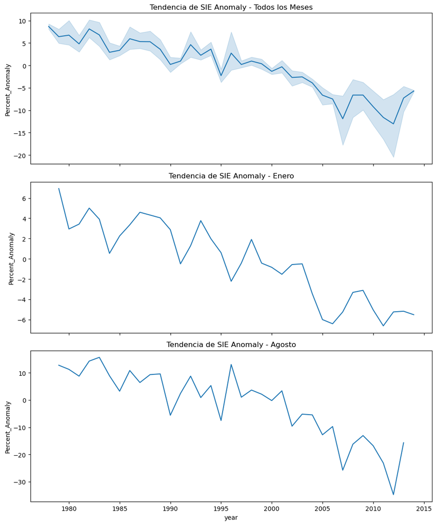

```python
#your response here
df_jan =  df_anomalies[df_anomalies['mo'] ==1]
df_aug = df_anomalies[df_anomalies['mo'] ==8]
df_all_months = df_anomalies.copy()

fig, (ax1, ax2, ax3) = plt.subplots(3, 1, figsize=(10, 12), sharex=True)

# AnomalÃas por aÃ±o
sns.lineplot(x='year', y='Percent_Anomaly', data=df_all_months, ax=ax1)
ax1.set_title('Tendencia de SIE Anomaly - Todos los Meses')

# AnomalÃas de Enero por aÃ±o
sns.lineplot(x='year', y='Percent_Anomaly', data=df_jan, ax=ax2)
ax2.set_title('Tendencia de SIE Anomaly - Enero')

# AnomalÃas de agosto por aÃ±o
sns.lineplot(x='year', y='Percent_Anomaly', data=df_aug, ax=ax3)
ax3.set_title('Tendencia de SIE Anomaly - Agosto')

plt.tight_layout()
plt.show()
```

If we look at the ordinate axis we see how the variability of values in the month of August is much more pronounced than in January, moving between 6 and -6.

### 3. Compute the trend as a simple linear regression (OLS) and quantitatively evaluate it.

Provide the estimated parameters for the linear regression. Evaluate the quality of fit quantitatively and graphically.

$$ \textbf{y} = a_1 \textbf{x}_1 + \dots + a_m \textbf{x}_{m} $$

[output not shown]

[figure not shown]

```python
#your solution here
import statsmodels.api as sm
import seaborn as sns
import matplotlib.pyplot as plt

# Definir variables independientes (X) y dependientes (Y)
X = data['year']
Y = data['Anomaly']

# Agregar una constante (intercepto) al modelo
X = sm.add_constant(X)

# Ajustar el modelo de regresión lineal
model = sm.OLS(Y, X).fit()
print(model)

# Obtener los resultados de la regresión
params = model.params
print("Estimated Parameters for Linear Regression:")
print(params)

# Obtener estadísticas de resumen del modelo
summary = model.summary()
print(summary)

# Crear un gráfico de dispersión con la línea de regresión
sns.regplot(x='year', y='Anomaly', data=data, scatter_kws={'alpha': 0.5})
plt.title('Linear Regression of Anomaly Over Years')
plt.xlabel('Year')
plt.ylabel('Anomaly')
plt.show()
```

```python
model.predict()
```

[output not shown]

Based on your results, what is the trend in the evolution of sea ice extent over recent years?

Hint: the trend is typically expressed in percent per decade (multiply per 10)

```python
#your solution here

# Calcular la tendencia en porcentaje por década
trend = model.params['year'] * 10
print(trend)

# Imprimir la tendencia
print("Trend in Sea Ice Extent Over Recent Years (Percent per Decade): {:.2f}%".format(trend))
```

```
-2.530183908044595
Trend in Sea Ice Extent Over Recent Years (Percent per Decade): -2.53%
```

### 4. Estimate the sea ice extent in the future

Based on the linear trend, make a prediction of SIE for October 2023, October 2025, and October 2030. Compare to September 1979 SIE to estimate the loss (in million square kilometers). For interpretation, note 3.59 million square kilometers is about twice the size of Alaska.

```python
years_of_interest = [2023, 2025, 2030]

# Realizar las predicciones de SIE para los años de interés
predicted_SIE = [params['const'] + params['year'] * year for year in years_of_interest]

# Imprimir las predicciones
for year, sie in zip(years_of_interest, predicted_SIE):
    print(f"Predicción de SIE para octubre {year}: {sie:.2f} millones de kilómetros cuadrados")

# Comparar con la extensión de SIE en septiembre de 1979
sie_1979 = data[data['year'] == 1979]['extent'].values[0]
loss_million_sq_km = sie_1979 - predicted_SIE[0]
print(f"Pérdida de hielo marino en octubre 2023 (en millones de km^2): {loss_million_sq_km:.2f}")
```

```
Predicción de SIE para octubre 2023: -10.35 millones de kilómetros cuadrados
Predicción de SIE para octubre 2025: -10.85 millones de kilómetros cuadrados
Predicción de SIE para octubre 2030: -12.12 millones de kilómetros cuadrados
Pérdida de hielo marino en octubre 2023 (en millones de km^2): 25.89
```